# Welcome to our survey!

Hi! We are a research team at George Washington University. This survey will ask you questions regarding your purchase preference for **used cars**.

This survey will take about **15 minutes** to complete. It can be stopped and picked up at any time. Your personal information will be kept confidential and won’t be shared with anyone else. The survey is subdivided in six sub-sections:

- Current vehicle information
- Future vehicle information
- Vehicle fuel type choice questions
- Electric vehicle choice questions
- Knowledge of electric vehicles
- Demographic Information

**We greatly appreciate your participation!**

# Consent

## Informed Consent for Participation in a Research Study

You are invited to participate in a research study directed by Dr. John Paul Helveston of the Department of Engineering Management and Systems Engineering at George Washington University (GWU). This study is funded by the Department of Energy and the National Institute of Standards and Technology. Participation is entirely voluntary and you may obtain further information regarding this study by contacting us at gwuvehiclegroup25@gmail.com .

The purpose of this study is to better understand vehicle ownership patterns and preferences across different communities. If you choose to participate, you will be asked to complete an online survey, which will take approximately **15 minutes**. You may refuse to answer any of the questions and stop participating at any time.

**Benefits**: The most important reason why someone would like to participate in this study is that they can share their vehicle ownership needs and help inform electric vehicle policies. You will not benefit directly from your participation in the study. However, the benefits to science and humankind that might result from this study include advancing our understanding of consumer decision-making in the vehicle market.

**Concerns/Risks**: You may not choose to volunteer for this study if you do not want to share information about your vehicle choices and certain personal details. Possible risks or discomforts you could experience during this study include: (1) Although very unlikely, there is a risk of email address information being compromised if it is shared and in case our systems are compromised. (2) Psychological stress could be caused by the time and effort spent answering the survey.

**Confidentiality**: Every effort will be made to keep your information confidential. However, this cannot be guaranteed. The data will be stored in a secured online database which only the PI and student researchers can access. If the results of this study are reported in journals or at scientific meetings, participants of this study will not be named or identified.

**Additional Information**: The Office of Human Research of George Washington University, at telephone number (202) 994-2715, can provide further information about your rights as a research participant. Your willingness to participate in this research study is implied if you proceed.

**Participation to this survey is voluntary. To take a part in this survey, you must:**

- Be at least 18 years old.
- Authorize us to analyze your data exclusively for research purposes.

By clicking on “**I Agree**”, you confirm that you have reviewed and understood the information provided in the welcome page and this consent page, and agree to participate in the survey.

## This study is about the purchase of your next vehicle.

**To your best estimate, when will you likely need to purchase your next vehicle?**

Within the next 3 months

In 3-6 months

In 6-12 months

In 1-2 years

After 2 years

I’m not sure

**Are you interested in buying a new or used vehicle?**

New vehicle only

Used vehicle only

I’m looking at both markets

**Which vehicle body style would you consider for your next vehicle?**

Car / sedan / hatchback

SUV / crossover

Minivan / van

Truck

Other

**Have you ever owned a Toyota vehicle?**

Yes, currently

Yes, in the past

No

## Section 1 of 6

## Below are some questions about your household.

**We’ll start with a few questions about the vehicles your household owns or leases.**  
- Please consider all passenger vehicles – including cars, SUVs, vans, and trucks – but exclude motorcycles.  
- Your household includes all the persons who occupy the housing unit as their usual place of residence.  
- The table below describes each type of passenger vehicle.

| Types of Powertrains | Powertrain Definition | Examples |
| --- | --- | --- |
| Conventional | Gasoline or other liquid-fuel engine, such as diesel or flex-fuel. | Honda Civic, Ford Explorer |
| Gas hybrid electric vehicle (HEV) | Smaller gasoline engine + electric motor + small battery. The gasoline engine recharges the battery to improve fuel efficiency. | Toyota Prius, Ford Escape Hybrid |
| Plug-in hybrid electric vehicle (PHEV) | Hybrid that can also be plugged into an electrical outlet to charge the battery. Runs on electricity for a short range (10 – 40 miles), then switches to gasoline. | Kia Niro, Toyota RAV4 Prime |
| Battery electric vehicle (BEV) | Electric motor only. Must be plugged into an electrical outlet to be refueled. | Nissan Leaf, Tesla Model Y |

**How many passenger vehicles are currently owned or leased by your household?**

0

1

2

3

4

5

6 or more

**Which of the following types of vehicles are currently owned or leased by your household?** *Select all that apply.*

Conventional

Gas hybrid

Plug-in hybrid

Battery electric

Other

**Do you have access to an electrical outlet where your vehicle is typically parked at your primary residence or workplace?**

Yes

No

I’m not sure

**Do any of your neighbors own or lease a plug-in hybrid or a battery electric vehicle?**

Yes

No

I’m not sure

## The following questions are about the household vehicle you drive most often.

**What is the fuel type of this vehicle?**

Conventional

Gas hybrid

Plug-in hybrid

Battery electric

Other

**Was this vehicle obtained as a new or used vehicle?**

New

Used

**How was this vehicle obtained?**

Bought from a dealership

Leased from a dealership

Bought from an online retailer (e.g., Carvana)

Bought from a private seller

Received it as a gift

Other

Do not remember / do not know

**To your best estimate, what was the total purchase or lease price for this vehicle?** *Please **include** all related expenses (such as the down payment, monthly payments, taxes, and any additional fees), but **do not include** any trade-in value or credits from selling another vehicle.*

$9,999 or less

$10,000 - $19,999

$20,000 - $29,999

$30,000 - $39,999

$40,000 - $49,999

$50,000 - $59,999

$60,000 - $69,999

$70,000 - $79,999

$80,000 - $89,999

$90,000 - $99,999

$100,000 or more

Do not remember / do not know

**What is your current monthly payment for this vehicle?**

Paid in full/ No loan

$99 or less

$100 - $199

$200 - $299

$300 - $399

$400 - $499

$500 - $599

$600 - $699

$700 - $799

$800 - $899

$900 - $999

$1,000 or more

Do not remember / do not know

**What is the average gas mileage (in miles per gallon, MPG) of this vehicle?** *Please provide your best estimate and select **I’m not sure** if your primary vehicle is a Battery Electric Vehicle.*

9.99 MPG or less

10 - 19.99 MPG

20 - 29.99 MPG

30 - 39.99 MPG

40 - 49.99 MPG

50 - 59.99 MPG

60 MPG or more

I’m not sure

**How often do you refuel or recharge this vehicle?**

Once a month

Once in two weeks

Once a week

Twice a week

Three times a week

Four times a week

Five or more times a week

**How many miles can this vehicle travel on a full tank or full battery charge?**

49 miles or less

50 - 99 miles

100 - 149 miles

150 - 199 miles

200 - 249 miles

250 - 299 miles

300 - 349 miles

350 - 399 miles

400 - 449 miles

450 miles or more

## Section 2 of 6

## This section asks a few questions about your future vehicle.

**What is your budget for the vehicle?**

$4,999 or less

$5,000 - $9,999

$10,000 - $14,999

$15,000 - $19,999

$20,000 - $24,999

$25,000 - $29,999

$30,000 - $34,999

$35,000 - $39,999

$40,000 - $44,999

$45,000 - $49,999

$50,000 or more

**How do you intend to pay for the vehicle?**

Pay in full

Finance

**How likely are you to purchase the following types of vehicles as your next vehicle?**

|  | Very unlikely | Somewhat unlikely | Neither likely nor unlikely | Somewhat likely | Very likely |
| --- | --- | --- | --- | --- | --- |
| New plug-in hybrid electric vehicle | Very unlikely Somewhat unlikely Neither likely nor unlikely Somewhat likely Very likely |  |  |  |  |
| Used plug-in hybrid electric vehicle | Very unlikely Somewhat unlikely Neither likely nor unlikely Somewhat likely Very likely |  |  |  |  |
| New battery electric vehicle | Very unlikely Somewhat unlikely Neither likely nor unlikely Somewhat likely Very likely |  |  |  |  |
| Used battery electric vehicle | Very unlikely Somewhat unlikely Neither likely nor unlikely Somewhat likely Very likely |  |  |  |  |

**You mentioned that you are unlikely to purchase a battery electric vehicle as your next vehicle. What is your biggest concern or reason for this?**

**Select a vehicle based on its segment / style that is most closely aligned with the next vehicle you are considering purchasing.**

**Select a vehicle based on its segment / style that is most closely aligned with the next vehicle you are considering purchasing.**

## Section 3 of 6

## Vehicle Educational Page

Great Work! Now that you have shared a bit about yourself, we’d like you to consider a scenario in which you can **choose a used vehicle from a set of vehicles with different attributes**.

Let’s learn about the attributes.

| Types of Powertrain | Powertrain Definition | Examples |
| --- | --- | --- |
| Conventional | Gasoline or other liquid-fuel engine, such as diesel or flex-fuel. | Honda Civic, Ford Explorer |
| Gas hybrid electric vehicle (HEV) | Smaller gasoline engine + electric motor + small battery. The gasoline engine recharges the battery to improve fuel efficiency. | Toyota Prius, Ford Escape Hybrid |
| Plug-in hybrid electric vehicle (PHEV) | Hybrid that can also be plugged into an electrical outlet to charge the battery. Runs on electricity for a short range (10 – 40 miles), then switches to gasoline. | Kia Niro, Toyota RAV4 Prime |
| Battery electric vehicle (BEV) | Electric motor only. Must be plugged into an electrical outlet to be refueled. | Nissan Leaf, Tesla Model Y |

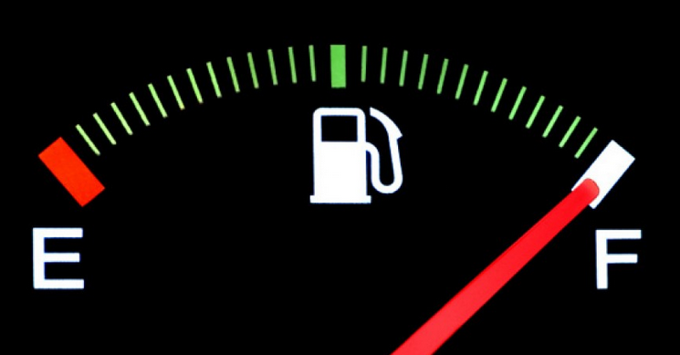

**Range -** The maximum distance a vehicle can travel in a full tank / full battery charge.

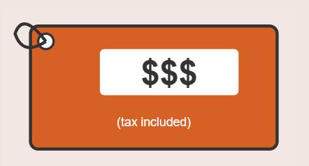

**Purchase price -** The total price for the vehicle (in dollars), including down payment, monthly payments, taxes, fees, etc.

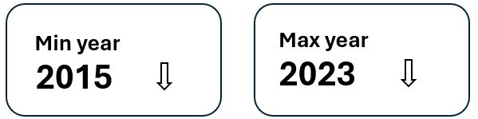

**Model Year -** The actual year the vehicle was made.

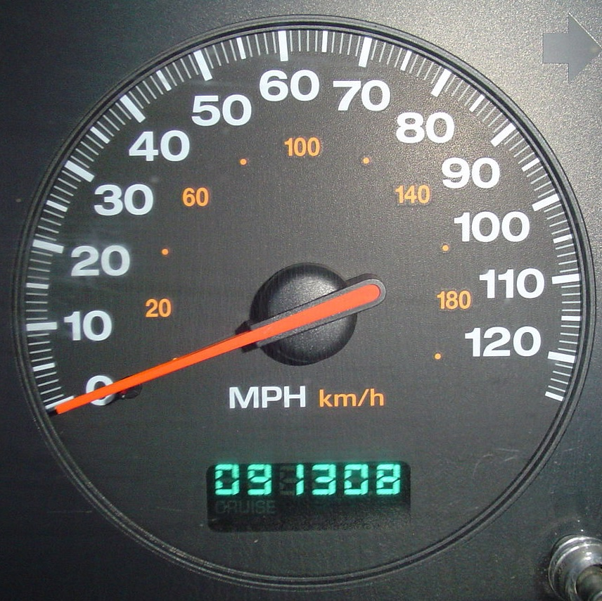

**Mileage -** The number of miles a vehicle has traveled.

[figure not shown]

**Operating Cost (Equivalent Gasoline Fuel Efficiency) -** Cost in cents per mile driven of fueling the vehicle. The equivalent fuel efficiency in miles per gallon (MPG) of a conventional gasoline vehicle is displayed in parenthesis.

## Choice Question Demonstration

### Question 1 of 6

### Question 2 of 6

### Question 3 of 6

### Question 4 of 6

### Question 5 of 6

### Question 6 of 6

## Section 4 of 6

## Battery Educational Page

Next, we’d like you to consider a scenario in which you can choose a **used battery electric vehicle (BEV)** from a set of BEVs with different attributes. Please review some important facts about BEVs and their batteries.

**Vehicle Driving Range and Battery Health**  
- EV batteries **gradually lose capacity over time (battery degradation)**, which reduces the vehicle’s driving range and increases charging time.  
- The condition of an EV battery is often described using **State of Health (SOH)**, expressed as a percentage.

## Section 4 of 6

## Battery Educational Page

Next, we’d like you to consider a scenario in which you can choose a **used battery electric vehicle (BEV)** from a set of BEVs with different attributes. Please review some important facts about BEVs and their batteries.

**Vehicle Driving Range and Battery Health**  
- EV batteries **gradually lose capacity over time (battery degradation)**, which reduces the vehicle’s driving range and increases charging time.  
- The condition of an EV battery is often described using **State of Health (SOH)**, expressed as a percentage.

**Battery Maintenance**  
- **Battery replacements** are rare but can be expensive, costing **between $5,000 and $20,000** depending on the model and labor costs.  
- However, most modern EV batteries are **designed to last the lifetime** of the vehicle under normal use.

**Battery Warranty**  
- BEVs come with a **battery warranty** of at least **8 years or 100,000 miles**, whichever comes first.  
- Many batteries continue to perform well **beyond the warranty period**, though some performance degradation is expected over time.  
- Most manufacturers will replace the battery **at no cost** when the SOH falls **below 70-75%** while under warranty.

## Battery Educational Page

Let’s take a moment to learn about the specific attributes of the BEVs that you’ll see in the upcoming choices.

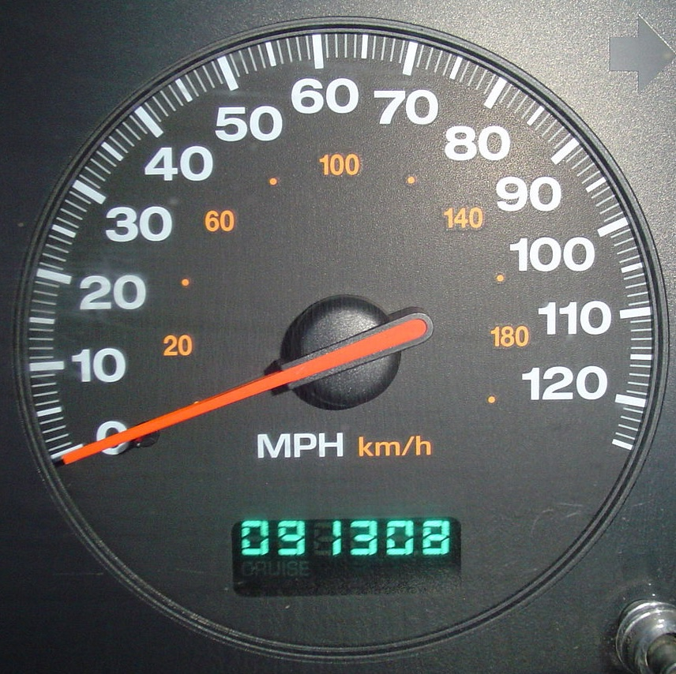

**Mileage -** The number of miles a vehicle has traveled.

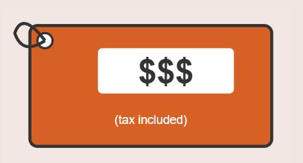

**Purchase price -** The total price for the vehicle (in dollars), including down payment, monthly payments, taxes, fees, etc.

**Battery refurbishment history -** The repair or replacement work that has been done on the vehicle’s main battery.

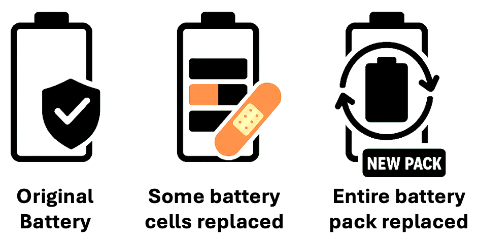

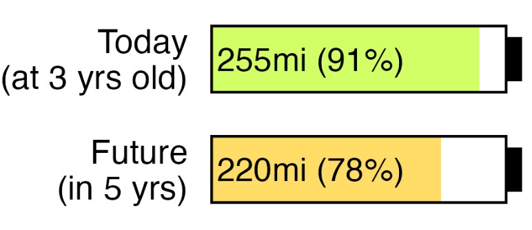

**Electric range -** The maximum distance (in miles) the vehicle can travel on a full battery charge, under typical driving conditions.  
**Battery Health -** How much (in percentages) of the battery’s original capacity remains.

## Battery Choice Question

We will now show you **six** choice questions, starting on the next page. **For all choice questions, please assume the used vehicle was built in 2022 and is currently three years old.**

### Question 1 of 6

### Question 2 of 6

### Question 3 of 6

### Question 4 of 6

### Question 5 of 6

### Question 6 of 6

**We noticed you did not choose any of the electric vehicle options in the last few questions. Could you tell us any reasons why?**

**How important are the following attributes to you when selecting a used battery electric vehicle?**

|  | Unimportant | Of little importance | Moderately important | Important | Very important |
| --- | --- | --- | --- | --- | --- |
| Vehicle mileage | Unimportant Of little importance Moderately important Important Very important |  |  |  |  |
| Purchase price | Unimportant Of little importance Moderately important Important Very important |  |  |  |  |
| Battery refurbishment history | Unimportant Of little importance Moderately important Important Very important |  |  |  |  |
| Vehicle range | Unimportant Of little importance Moderately important Important Very important |  |  |  |  |
| Battery health | Unimportant Of little importance Moderately important Important Very important |  |  |  |  |

## Section 5 of 6

## We’d like to learn more about your views on vehicle technologies and related topics.

**Please select which vehicle(s) can run on gasoline.** *Select all that apply.*

Gas hybrid electric vehicle

Plug-in hybrid electric vehicle

Battery electric vehicle

I’m not sure

**Please select which vehicles can be plugged in.** *Select all that apply.*

Gas hybrid electric vehicle

Plug-in hybrid electric vehicle

Battery electric vehicle

I’m not sure

**Can you name the make and model of at least one vehicle powered completely by electricity (a battery electric vehicle)?**

Yes

No

**Please name the make and model of the vehicle.**

**To the best of your knowledge, what was the previous maximum federal tax credit (up till 09/30/2025) available in the US for purchasing a new electric vehicle?**

$1,000

$2,500

$5,000

$7,500

$10,000

I’m not sure

**Please indicate the extent to which you agree or disagree with the following statements.**

|  | Strongly disagree | Somewhat disagree | Neither agree nor disagree | Somewhat agree | Strongly agree |
| --- | --- | --- | --- | --- | --- |
| People who are important to me think that I should buy an EV. | Strongly disagree Somewhat disagree Neither agree nor disagree Somewhat agree Strongly agree |  |  |  |  |
| Driving an EV would eventually result in cost savings. | Strongly disagree Somewhat disagree Neither agree nor disagree Somewhat agree Strongly agree |  |  |  |  |
| Driving an EV would be beneficial to the environment in the long term. | Strongly disagree Somewhat disagree Neither agree nor disagree Somewhat agree Strongly agree |  |  |  |  |

|  | Strongly disagree | Somewhat disagree | Neither agree nor disagree | Somewhat agree | Strongly agree |
| --- | --- | --- | --- | --- | --- |
| If I owned a BEV, I would often worry about running out of charge. | Strongly disagree Somewhat disagree Neither agree nor disagree Somewhat agree Strongly agree |  |  |  |  |
| BEVs are less valuable than gasoline cars on the resale market, because the technology is always advancing. | Strongly disagree Somewhat disagree Neither agree nor disagree Somewhat agree Strongly agree |  |  |  |  |
| The price of an EV is too high. | Strongly disagree Somewhat disagree Neither agree nor disagree Somewhat agree Strongly agree |  |  |  |  |

**Please indicate the extent to which you agree or disagree with the following statements.**

|  | Strongly disagree | Somewhat disagree | Neither agree nor disagree | Somewhat agree | Strongly agree |
| --- | --- | --- | --- | --- | --- |
| Purchasing refurbished EV batteries will minimize negative effects on natural ecosystems. | Strongly disagree Somewhat disagree Neither agree nor disagree Somewhat agree Strongly agree |  |  |  |  |
| Refurbished EV batteries do NOT perform and function as original EV batteries. | Strongly disagree Somewhat disagree Neither agree nor disagree Somewhat agree Strongly agree |  |  |  |  |
| Please select "Strongly agree" as your response to this item. | Strongly disagree Somewhat disagree Neither agree nor disagree Somewhat agree Strongly agree |  |  |  |  |

|  | Strongly disagree | Somewhat disagree | Neither agree nor disagree | Somewhat agree | Strongly agree |
| --- | --- | --- | --- | --- | --- |
| Generally, I am willing to put in extra effort to find lower prices. | Strongly disagree Somewhat disagree Neither agree nor disagree Somewhat agree Strongly agree |  |  |  |  |
| I like to be among the first people to have the latest technology. | Strongly disagree Somewhat disagree Neither agree nor disagree Somewhat agree Strongly agree |  |  |  |  |
| I am a person who is fully prepared to take risks. | Strongly disagree Somewhat disagree Neither agree nor disagree Somewhat agree Strongly agree |  |  |  |  |

## Section 6 of 6

## Demographic information

**We’re almost done! We’d like to ask a few final questions about you, which will be used only for analyzing the survey data.**

**What is your year of birth?**

**What is your gender?**

Female

Male

Non-binary

Transgender

Gender Nonconforming

Other

Prefer not to answer

**Are you of Hispanic, Latino or Spanish origin?**

Yes

No

**Which race best describes you?** *Select all that apply.*

American Indian or Alaskan Native

Asian

Black or African American

Middle Eastern and North African (MENA)

Native Hawaiian or other Pacific Islander

White

Some other race

Do not know / prefer not to answer

**Including yourself, how many people live in your household?**

1

2

3

4

5

More than 5

**Which of the following describes your current employment status?** *Select all that apply.*

I am a part-time or full-time student

Employed, working fewer than 40 hours per week

Employed, working 40 or more hours per week

Not employed, looking for work

Not employed, NOT looking for work

Retired

Disabled, not able to work

Prefer not to answer

**What is your annual household income?** *Please provide your best estimate.*

$9,999 or less

$10,000 - $19,999

$20,000 - $29,999

$30,000 - $39,999

$40,000 - $49,999

$50,000 - $59,999

$60,000 - $69,999

$70,000 - $79,999

$80,000 - $89,999

$90,000 - $99,999

$100,000 - $109,999

$110,000 - $119,999

$120,000 - $129,999

$130,000 - $139,999

$140,000 - $149,999

$150,000 - $159,999

$160,000 - $169,999

$170,000 - $179,999

$180,000 - $189,999

$190,000 - $199,999

$200,000 - $209,999

$210,000 - $219,999

$220,000 - $229,999

$230,000 - $239,999

$240,000 - $249,999

$250,000 or more

Prefer not to answer

**What is the highest level of education you have completed?** *If currently enrolled, please use the highest degree received.*

Less than a high school diploma

High school degree or equivalent (e.g. GED)

Some college - but less than two years

Some college - two years or more/A.A. degree

Technical or trade school

College graduate/bachelor’s degree/B.A./B.S.

Postgraduate courses

Master’s degree

M.B.A. or law degree

Ph.D. or M.D

Prefer not to answer

**What type of housing do you currently live in?**

Single family house not attached to any other house

Single family house attached to one or more houses (townhouse, rowhome, condo, duplex, triplex, etc.)

Building with 2-4 apartments/condos/studios

Building with 5-19 apartments/condos/studios

Building with 20 or more apartments/condos/studios

A mobile home or trailer

Boat, RV, van, etc.

Other

**Do you own or rent the current place you are living in?**

Own

Rent

Other

Do not know / prefer not to answer

**What is your monthly electricity bill on average?** *Please provide your best estimate.*

$0 - $99

$100 - $199

$200 - $299

$300 - $399

$400 - $499

$500 or more

**How would you describe your political views?**

Very conservative

Conservative

Moderate

Liberal

Very liberal

Other

Prefer not to answer

**Which political party do you typically vote for?**

Democratic

Republican

I am independent

Prefer not to answer

**How much do you, personally, worry about the issue of global climate change?**

None at all

A little

A moderate amount

A lot

A great deal

**What is the zip code of your primary residence?** *Please provide a 5-digit number.*

please include the word “banana” in your response”

**Please briefly describe what this survey is about:**

## You have reached the end of this survey. We appreciate your time and participation!

## Sorry, but you are not qualified to continue with the survey. We appreciate your time and participation!